# Manual for Stepped Wedge Power Calculation

August 28, 2019

# Stepped Wedge Designs

This app is a tool for estimating the power of stepped wedge designs. Here, we consider designs in which the order of treatment is randomized by cluster, and the clusters ‘cross over’ from the control group to the treatment group at staggered time points. A group of clusters that cross over to treatment at the same time is called a sequence.

For example, the image below depicts a study design with 5 sequences in which all sequences start in the control group. In each sequence, there are 5 independent clusters, separated by dotted lines. See Hussey and Hughes (2007) for a more thorough introduction to stepped wedge designs.

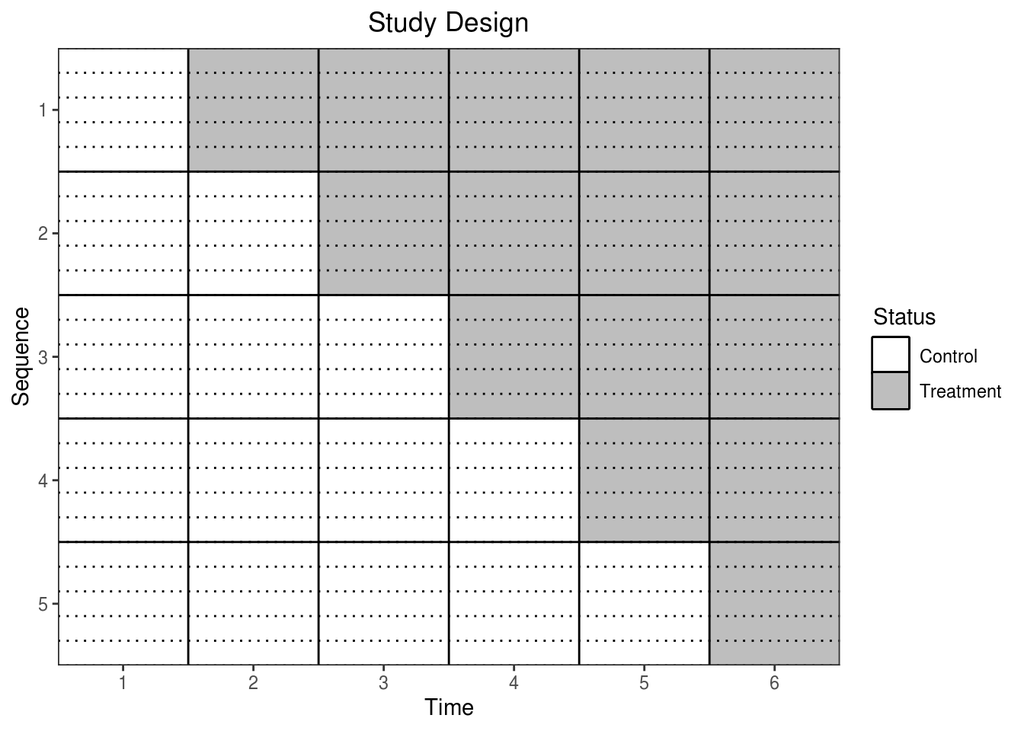

# The Model

To account for the correlation within clusters, we use a random effects model (Hughes et al. 2015). Let $Y_{ijk}$ denote the response recorded for individual k at time j from cluster i. In this app, $Y_{ijk}$ may come from either a Normal (Gaussian) distribution, or a Binomial distribution. Currently, only Binomial distributions with one trial are supported (where $Y_{ijk}$ is either 0 or 1). Also, let $X_{ij}$ have a value of one if cluster i is receiving treatment at time j, and zero otherwise. We model time as categorical.
Then the mean response for cluster i at time j is:
$$\mu_{ij} = \mu + \beta_j+\theta *X_{ij}+u_i+w_{ij}+v_i*X_{ij}$$

Here, $\mu$ is the baseline average (that is, the average for groups on control at the first time point), $\theta$ represents the treatment effect, and $\beta_j$ represents the mean difference between time j and time 1, with $\beta_1=0$. The random effects are represented by $u_i$, $w_{ij}$, and $v_i$; each follows a Normal distribution with mean zero. The random intercepts, $u_i$, represent each cluster’s unique baseline and have a standard deviation of tau ($\tau$). The random time effects, $w_{ij}$, represent cluster- and time- specific deviations and have a standard deviation of gamma ($\gamma$). The random treatment effects, $v_i$, represent the cluster-specific variations in the impact of treatment, and have a standard deviation of eta ($\eta$). We assume that the correlation between $u_i$ and $v_i$ is rho ($\rho$), and the correlation between $w_{ij}$ and both $u_i$ and $v_i$ is zero. In addition, we assume the correlation between random time effects at different times (that is, $w_{ij}$ and $w_{ij'}$ with $j \neq j'$) is zero.

When $Y_{ijk}$ is Gaussian,
$$Y_{ijk} = \mu_{ij}+\epsilon_{ijk}$$
where $\epsilon_{ijk}$ is Normal with mean zero and standard deviation sigma ($\sigma$). You can think of sigma as the variability in an individual’s outcome after accounting for the fixed and random effects from their specific cluster, time, and treatment. So $E(Y_{ijk})=\mu_{ij}$ and $\text{sd}(Y_{ijk}|u_i,w_{ij},v_i) = \sigma$. The $\epsilon_{ijk}$ are all independent of each other and all the random effects. When $Y_{ijk}$ is binary, it still has mean $\mu_{ij}$ but the standard deviation is defined by $\text{sd}(Y_{ijk}|u_i,w_{ij},v_i) = \sqrt{\mu_{ij}(1-\mu_{ij})}$.

Note that these calculations assume that each subject only has one observation in the data set. If the same subjects are observed at multiple time points, we refer to this as a ‘cohort’ design; this requires more complicated calculations (Hooper et al. 2016).

### Alternative parameterization

Instead of using the variance components above to quantify correlation, some people prefer to use measures such as the within-period intra-cluster correlation (ICC) and cluster auto-correlation (CAC) (Hooper et al. 2016). When there are no random treatment effects, the two parametrizations are equivalent. However, the random effects parameterization allows for random treatment effects (through $\eta$) and a correlation between them and the random intercepts ($\rho$), while a single ICC and CAC do not (Hemming et al. 2018). The random effects parameterization is more flexible than the ICC/CAC parameterization because it allows $\eta$ and $\rho$ to be nonzero, but because ICC and CAC are so widely used in the literature they are included in this app. The formulas that follow are all for the case where both $\eta=0$ and $\rho=0$.

The ICC is the correlation between individuals sampled from the same cluster at the same time, or the ratio of between-cluster variance to total variance (Hooper et al. 2016). In terms of the random effects parameters defined above,
$$\text{ICC} = \frac{\tau^2+\gamma^2}{\tau^2+\gamma^2+\sigma^2}$$

When the outcome is Normal, $\sigma$ is well defined. When the outcome is binary, we substitute $\sigma=\sqrt{\bar\mu(1-\bar\mu)}$, where $\bar\mu=(\mu_0+\mu_1)/2$, the average probability of the outcome in the control and treatment groups. The CAC is the correlation between two population means from the same cluster at different times (Hooper et al. 2016). Here,
$$\text{CAC} = \frac{\tau^2}{\tau^2+\gamma^2}$$

In this app, ICC and CAC input will be translated to random effect parameters. If the ICC is zero, both tau and gamma are zero and the CAC is not well-defined. If the ICC is one, either sigma is zero or either tau or gamma is extremely large. Because it is not possible to solve these equations for the random effects parameters in this case, it is best to use the random effects parameterization directly when the ICC is close to one.

The formulas below can be used to manually convert from ICC, CAC, and $\sigma$ to the random effects parameterization:

For CAC=1, $\gamma = 0$ and $\tau = \sqrt{\sigma^2* \text{ICC}/(1-\text{ICC})}$

For CAC<1, $\gamma = \sqrt{\text{ICC}*\sigma^2*(1-\text{CAC})/(1-\text{ICC})}$ and $\tau = \sqrt{\gamma^2* \text{CAC}/(1-\text{CAC})}$

### Fractional treatment effect

In the case described above, the clusters receive the full treatment effect $\theta$ as soon as they cross over to treatment (i.e. $X_{ij}$ changes from 0 to 1). However, sometimes the effect of an intervention is not immediate. For example, perhaps when a cluster is first switched to treatment the effect size is $\frac \theta 2$, then $\theta$ at every subsequent time point. Fractional treatment effects can extend over as many time points as desired by specifying a series of $X_{ij}$ between 0 and 1, although this may cause some clusters to never experience the full treatment effect. For more detail, see Hughes et al. (2015).

In the app, there is a field to input a fractional treatment effect. The fractional treatment effect should be a list of decimals separated by commas (e.g. 0.5, 0.75). Each number represents a value of $X_{ij}$ that will be applied to every cluster after it switches to treatment. For example, if the fractional treatment effect is “0.5, 0.75”, the first time a cluster receives the treatment, they will experience 50% of the full treatment effect; the second time point that a cluster receives the treatment they will experience 75% of the full treatment effect; at every subsequent time point, they will experience 100% of the treatment effect $\theta$, which corresponds to $X_{ij}=1$.

# Calculating Power

This app uses a power calculation which is a simple extension of Hughes et al. (2015), implemented through the swCRTdesign R package.

When you open the app to the ‘Main results’ tab, you should see a panel of options on the left and “Power: 0.05”. This power calculation will automatically update as you change parameters and the study design. This calculation can take a minute or two to update, during which the text appears grey instead of black and the message “Calculation in progress” is displayed.

The input for the power calculation in the ‘Main results’ tab follows the notation given above. For changes to the study design, such as changing what times are observed and making the number of clusters per sequence and number of observations vary, see the ‘Additional study design options’ tab.

Most of the inputs in the ‘Main results’ tab are sliders to make it easier to illustrate how changes in parameters affect the power curve. If the range of the sliders is inappropriate for your study, you can change this in the ‘Customize sliders’ tab. The measures of variability have a customizable maximum and size of interval (that is, the smallest distance the slider can ‘jump’). If there is a specific value you want to plug in for a parameter, you can just set that as the maximum. For example, if I estimated that tau is 0.37 in my study, I would set ‘Maximum tau’ to 0.37, then go to the ‘Main results’ tab and move the tau slider to the far right.

### Choosing values for the variance components

Values for the variance components are study and context specific. Ideally, values are estimated from existing data in similar settings. Values for $\tau$ and $\gamma$ can sometimes be estimated from published values of the ICC and CAC for cluster randomized studies. A value for $\eta$ may be chosen by considering a plausible range of variation for the intervention effect between clusters as described in Hughes et al. (2015).

# Creating a Power Curve

Once you have selected parameter values to calculate the power for a specific design, you can plot a power curve by checking the box labeled ‘Plot a power curve’ towards the bottom of the ‘Main results’ tab. The power curve demonstrates what power the study would have at different treatment effect sizes ($\theta$). Here, the effect size is the difference between the mean outcome in the treatment group and the mean outcome in the control group. For binary outcomes, the effect size is relative to a specific mean outcome in the control group, defined by ‘Mean outcome (control)’.

Note that this plot may take some time to produce. Very complicated designs may require several minutes to calculate the power curve, during which “Calculation in progress” will be printed above the plot. The only way to stop a calculation before it finishes is to restart the app. You can reduce calculation time by simplifying the design or by reducing the number of points in the power curve (see next section).

### Customizing a power curve

The tab labeled ‘Customize plots’ allows you to change how many points appear on the power curve, how close together they are, and what range of effect sizes are considered. Once you make adjustments, the plot will automatically update itself when you return to the ‘Main results’ tab.

To change the distance between points and number of points in the plot, use the ‘Distance in effect size between plotted points’ input. This can be any positive number, but note that you need to use decimal notation for fractions (e.g. 0.5, as opposed to 1/2).

There are two ways to change the range of effect sizes displayed in the plot. One is to simply define a minimum and maximum effect size. In this case, for a Gaussian outcome, moving the ‘Mean outcome (trt)’ and ‘Mean outcome (control)’ inputs in the main tab will have no effect on the range of the power plot. The other way to define the range is by using the ‘Effect size range’ input to define a range around the effect size defined by ‘Mean outcome (trt)’ and ‘Mean outcome (control)’. In this case, the power curve will always be centered around the effect size defined in the main tab. Note that for large changes in the range of effect sizes, the distance between plotted points will need to be adjusted manually.

For a Gaussian outcome, the mean outcomes affect the power only through the effect size, their difference. For a binary outcome, the power is affected by the magnitude of the mean outcomes, not just the difference. When creating a plot for a binary outcome, the ‘Mean outcome (control)’ is used along with the effect sizes to calculate power. If the range of effect sizes differs from what you entered, it may be because of restrictions specific to the binomial calculations. If no plot appears, try increasing the range of effect sizes or decreasing the values of the standard deviations.

There is also a ‘Download’ button in the ‘Customize plots’ tab. This allows you to save the coordinates of the points on the power curve in a .csv file.

# Visualizing the Stepped Wedge Design

To print a simple visualization of the design you have defined, select the box labeled ‘Visualize study design’ at the bottom of the ‘Main results’ tab (see figure).

The white boxes represent times when all the clusters in that sequence are on control, and the grey represent times when they are on treatment. Sequences are subdivided into clusters by dotted lines; if desired, these lines can be removed in the ‘Customize plots’ tab. By default, at the first time point all clusters are on control, and at the last time point all clusters are on treatment. Changes to this in the ‘Additional study design options’ tab will be reflected in the plot. If there are some sequences that have no clusters (that is, there is a recorded time at which no sequences switch over to treatment), it will be reflected in this plot but the indexing of the sequences may be different than the indexing in the ‘Additional study design options’ tab.

# More Complex Designs

The ‘Additional study design options’ tab contains some less common study design variants. Some of the inputs in this tab depend on specifications from the ‘Main results’ tab. If there are errors in the ‘Main results’ or ‘Additional study design options’ tabs, often switching back and forth between the tabs will resolve the error.

### Times observed

The default design is that every cluster starts on control and ends on treatment. To create a study design where the first sequence never receives control, change ‘Start with control’ to ‘No’. To create a study design where there are multiple time points where all sequences are receiving treatment, use ‘Extra time’. It may be helpful to use the ‘Visualize study design’ option to confirm the design is correct.

### Number of clusters

The default design is that each sequence has the same number of clusters, defined by ‘Number of clusters per sequence’ on the ‘Main results’ tab. If the number of clusters differs by sequence, select ‘Varying’ under ‘Customize the number of clusters per sequence’ in the ‘Additional study design options’ tab. The new ‘Number of clusters per sequence’ replaces the ‘Number of clusters per sequence’ from the ‘Main results’ tab, and depends on the ‘Number of sequences’ you defined.

Recall that the order of the sequences corresponds to the order that they will cross over into the treatment group. It is possible to choose zero clusters for a sequence if there are time points at which no cluster crosses over. For example, if the study has two time points between cross-overs, making every other sequence have no clusters will create these extra time points.

### Number of observations

The default design is that each cluster at each time point has the same number of observations, defined by ‘Number of observations per cluster at each time point’ on the ‘Main results’ tab. The ‘Additional study design options’ tab can replace this with one of two options: ‘Varying by cluster’ or ‘Varying by cluster and time’.

If you have different sized clusters, but within each cluster the number of observations is the same at every time point, you will use ‘Varying by cluster’. This option depends on the number of sequences and number of clusters per sequence you have already defined, either in the ‘Main results’ tab or the ‘Additional study design options’ tab.

If the number of observations varies by both cluster and time point, ‘Varying by cluster and time’ allows you to enter a number of observations for each cluster at each time individually. This option depends on the number of sequences, number of clusters per sequence, and number of time points you have already defined, either in the ‘Main results’ tab or the ‘Additional study design options’ tab.

Recall that the order of the sequences corresponds to the order that they will cross over into the treatment group. The clusters are ordered by sequence, but within a sequence the order of the clusters does not matter. For example, if you have three clusters per sequence, the order of the first three clusters is arbitrary, but the sample sizes you enter for those clusters should correspond to the sample sizes for the three clusters that will be switched to treatment first.

Also, note that if you need to use the ‘Varying by cluster’ or ‘Varying by cluster and time’ options, you should specify all other elements of the study design first. Input in these matrices will not be preserved if changes to the study design affect their dimensions.

# References

Hemming K, Taljaard M, McKenzie JE, Hooper R, Copas A, Thompson JA et al. Reporting of stepped wedge cluster randomised trials: extension of the CONSORT 2010 statement with explanation and elaboration. *BMJ* 2018; **363** :k1614

Hooper R, Teerenstra S, de Hoop E, Eldridge S. Sample size calculation for stepped wedge and other longitudinal cluster randomised trials. *Statistics in Medicine* 2016; **35**:4718-4728.

Hughes JP, Granston TS, Heagerty PJ. Current issues in the design and analysis of stepped wedge trials. *Contemporary Clinical Trials* 2015; **45**:55-60.

Hussey MA, Hughes JP. Design and analysis of stepped wedge cluster randomized trials. *Contemporary Clinical Trials* 2007; **28**:182-191.